# gb_cource_project

```python
import numpy as np
import pandas as pd
```

```python
# input
DATASET_PATH = r'C:\Users\erida\Desktop\course_gb/course_project_test.csv'

# output
PREP_DATASET_PATH = r'C:\Users\erida\Desktop\course_gb/course_project_prep1.csv'
```

```python
# df = pd.read_csv(DATASET_PATH)
df = pd.read_csv(PREP_DATASET_PATH)
df.head()
```

|  | Home Ownership | Annual Income | Years in current job | Tax Liens | Number of Open Accounts | Years of Credit History | Maximum Open Credit | Number of Credit Problems | Months since last delinquent | Bankruptcies | Purpose | Term | Current Loan Amount | Current Credit Balance | Monthly Debt | Credit Score | Credit Default |
| --- | --- | --- | --- | --- | --- | --- | --- | --- | --- | --- | --- | --- | --- | --- | --- | --- | --- |
| 0 | Own Home | 482087.0 | NaN | 0.0 | 11.0 | 26.3 | 685960.0 | 1.0 | NaN | 1.0 | debt consolidation | Short Term | 99999999.0 | 47386.0 | 7914.0 | 749.0 | 0 |
| 1 | Own Home | 1025487.0 | 10+ years | 0.0 | 15.0 | 15.3 | 1181730.0 | 0.0 | NaN | 0.0 | debt consolidation | Long Term | 264968.0 | 394972.0 | 18373.0 | 737.0 | 1 |
| 2 | Home Mortgage | 751412.0 | 8 years | 0.0 | 11.0 | 35.0 | 1182434.0 | 0.0 | NaN | 0.0 | debt consolidation | Short Term | 99999999.0 | 308389.0 | 13651.0 | 742.0 | 0 |
| 3 | Own Home | 805068.0 | 6 years | 0.0 | 8.0 | 22.5 | 147400.0 | 1.0 | NaN | 1.0 | debt consolidation | Short Term | 121396.0 | 95855.0 | 11338.0 | 694.0 | 0 |
| 4 | Rent | 776264.0 | 8 years | 0.0 | 13.0 | 13.6 | 385836.0 | 1.0 | NaN | 0.0 | debt consolidation | Short Term | 125840.0 | 93309.0 | 7180.0 | 719.0 | 0 |

```python
df.shape
```

```
(7500, 17)
```

```python
df.iloc[0]
```

```
Home Ownership                            Own Home
Annual Income                               482087
Years in current job                           NaN
Tax Liens                                        0
Number of Open Accounts                         11
Years of Credit History                       26.3
Maximum Open Credit                         685960
Number of Credit Problems                        1
Months since last delinquent                   NaN
Bankruptcies                                     1
Purpose                         debt consolidation
Term                                    Short Term
Current Loan Amount                          1e+08
Current Credit Balance                       47386
Monthly Debt                                  7914
Credit Score                                   749
Credit Default                                   0
Name: 0, dtype: object
```

```python
df.info()
```

```
<class 'pandas.core.frame.DataFrame'>
RangeIndex: 7500 entries, 0 to 7499
Data columns (total 17 columns):
 #   Column                        Non-Null Count  Dtype
---  ------                        --------------  -----
 0   Home Ownership                7500 non-null   object
 1   Annual Income                 5943 non-null   float64
 2   Years in current job          7129 non-null   object
 3   Tax Liens                     7500 non-null   float64
 4   Number of Open Accounts       7500 non-null   float64
 5   Years of Credit History       7500 non-null   float64
 6   Maximum Open Credit           7500 non-null   float64
 7   Number of Credit Problems     7500 non-null   float64
 8   Months since last delinquent  3419 non-null   float64
 9   Bankruptcies                  7486 non-null   float64
 10  Purpose                       7500 non-null   object
 11  Term                          7500 non-null   object
 12  Current Loan Amount           7500 non-null   float64
 13  Current Credit Balance        7500 non-null   float64
 14  Monthly Debt                  7500 non-null   float64
 15  Credit Score                  5943 non-null   float64
 16  Credit Default                7500 non-null   int64
dtypes: float64(12), int64(1), object(4)
memory usage: 996.2+ KB
```

```python
# Преобразование объектов в строки
for colname in ['Home Ownership', 'Years in current job', 'Purpose', 'Term']:
    df[colname] = df[colname].astype(str)
```

Сущность признаков

*Home Ownership* - тип собственности для дома. Может быть ипотека (Home Mortgage, Have Mortgage), аренда или в собственности.

*Annual Income* - годовой доход. (странно, что столько пропусков для одного из основных критериев для заёмщика.

*Years in current job* - количество лет на текущем месте работы (номинативный признак, который стоит перевести в числовой)

*Tax Liens* - налоговые обременения

*Number of Open Accounts* - количество открытых счетов

*Years of Credit History* - количество лет кредитной истории

*Maximum Open Credit* - наибольший открытый кредит (самая большая сумма долга?)

*Number of Credit Problems* - количество проблем с кредитом

*Months since last delinquent* - количество месяцев с последней просрочки платежа. Можно предположить, что отсутствие данных в этом столбце это ноль.

*Bankruptcies* - банкротства. Пропуски информации о банкротстве также можно представить их отсутствием.

*Purpose* - цель кредита. Самый разнообразный номинативный признак, который нужно смотреть отдельно.

*Term* - срок кредита. Можно предстваить отдельным признаком "Длительный? Да/Нет"

*Current Loan Amount* - текущая сумма займа. Сколько денег по текущему кредиту будет должен банку клиент (?)

*Current Credit Balance* - текущий кредитный баланc. Это сумма, которую вы должны кредитной компании на дату, когда вы просматриваете данные своей кредитной карты.

*Monthly Debt* - ежемесячный долг

*Credit Score* - кредитный рейтинг. Можно попробовать восстановить на основе других значений или по моде.

*Credit Default* - факт невыполнения кредитных обязательств (0 - погашен вовремя, 1 - просрочка)

```python
df.dtypes
```

```
Home Ownership                   object
Annual Income                   float64
Years in current job             object
Tax Liens                       float64
Number of Open Accounts         float64
Years of Credit History         float64
Maximum Open Credit             float64
Number of Credit Problems       float64
Months since last delinquent    float64
Bankruptcies                    float64
Purpose                          object
Term                             object
Current Loan Amount             float64
Current Credit Balance          float64
Monthly Debt                    float64
Credit Score                    float64
Credit Default                    int64
dtype: object
```

```python
# проверка количества разных значений целевой переменной
df['Credit Default'].value_counts()
```

```
0    5387
1    2113
Name: Credit Default, dtype: int64
```

```python
# проверка количества разных значений признака банкротства
df['Bankruptcies'].value_counts()
```

```
0.0    6660
1.0     786
2.0      31
3.0       7
4.0       2
Name: Bankruptcies, dtype: int64
```

```python
# Обзор основных статистик для признаков количественных типов
df.describe()
```

|  | Annual Income | Tax Liens | Number of Open Accounts | Years of Credit History | Maximum Open Credit | Number of Credit Problems | Months since last delinquent | Bankruptcies | Current Loan Amount | Current Credit Balance | Monthly Debt | Credit Score | Credit Default |
| --- | --- | --- | --- | --- | --- | --- | --- | --- | --- | --- | --- | --- | --- |
| count | 5.943000e+03 | 7500.000000 | 7500.000000 | 7500.000000 | 7.500000e+03 | 7500.000000 | 3419.000000 | 7486.000000 | 7.500000e+03 | 7.500000e+03 | 7500.000000 | 5943.000000 | 7500.000000 |
| mean | 1.366392e+06 | 0.030133 | 11.130933 | 18.317467 | 9.451537e+05 | 0.170000 | 34.692600 | 0.117152 | 1.187318e+07 | 2.898332e+05 | 18314.454133 | 1151.087498 | 0.281733 |
| std | 8.453392e+05 | 0.271604 | 4.908924 | 7.041946 | 1.602622e+07 | 0.498598 | 21.688806 | 0.347192 | 3.192612e+07 | 3.178714e+05 | 11926.764673 | 1604.451418 | 0.449874 |
| min | 1.645970e+05 | 0.000000 | 2.000000 | 4.000000 | 0.000000e+00 | 0.000000 | 0.000000 | 0.000000 | 1.124200e+04 | 0.000000e+00 | 0.000000 | 585.000000 | 0.000000 |
| 25% | 8.443410e+05 | 0.000000 | 8.000000 | 13.500000 | 2.792295e+05 | 0.000000 | 16.000000 | 0.000000 | 1.801690e+05 | 1.142565e+05 | 10067.500000 | 711.000000 | 0.000000 |
| 50% | 1.168386e+06 | 0.000000 | 10.000000 | 17.000000 | 4.781590e+05 | 0.000000 | 32.000000 | 0.000000 | 3.095730e+05 | 2.093230e+05 | 16076.500000 | 731.000000 | 0.000000 |
| 75% | 1.640137e+06 | 0.000000 | 14.000000 | 21.800000 | 7.935015e+05 | 0.000000 | 50.000000 | 0.000000 | 5.198820e+05 | 3.604062e+05 | 23818.000000 | 743.000000 | 1.000000 |
| max | 1.014934e+07 | 7.000000 | 43.000000 | 57.700000 | 1.304726e+09 | 7.000000 | 118.000000 | 4.000000 | 1.000000e+08 | 6.506797e+06 | 136679.000000 | 7510.000000 | 1.000000 |

```python
# Обзор номинативных типов

for cat_colname in df.select_dtypes(include='object').columns:
    print(str(cat_colname) + '\n\n' + str(df[cat_colname].value_counts()) + '\n' + '*' * 100 + '\n')
```

```
Home Ownership

Home Mortgage    3637
Rent             3204
Own Home          647
Have Mortgage      12
Name: Home Ownership, dtype: int64

Years in current job

10+ years    2332
2 years       705
3 years       620
< 1 year      563
5 years       516
1 year        504
4 years       469
6 years       426
7 years       396
nan           371
8 years       339
9 years       259
Name: Years in current job, dtype: int64

Purpose

debt consolidation      5944
other                    665
home improvements        412
business loan            129
buy a car                 96
medical bills             71
major purchase            40
take a trip               37
buy house                 34
small business            26
wedding                   15
moving                    11
educational expenses      10
vacation                   8
renewable energy           2
Name: Purpose, dtype: int64

Term

Short Term    5556
Long Term     1944
Name: Term, dtype: int64
```

```python
# Обработка пропусков

# Подсчёт количества пропущенных значений
len(df) - df.count()
```

```
Home Ownership                     0
Annual Income                   1557
Years in current job               0
Tax Liens                          0
Number of Open Accounts            0
Years of Credit History            0
Maximum Open Credit                0
Number of Credit Problems          0
Months since last delinquent    4081
Bankruptcies                      14
Purpose                            0
Term                               0
Current Loan Amount                0
Current Credit Balance             0
Monthly Debt                       0
Credit Score                    1557
Credit Default                     0
dtype: int64
```

```python
# Посмотрим на возможные выбросы сначала построив гистогрыммы, а затем boxplot

df.hist(figsize=(16,16))
```

```
array([[<matplotlib.axes._subplots.AxesSubplot object at 0x000002923F8C6FD0>,
      dtype=object)
```

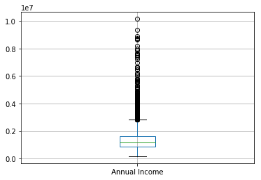

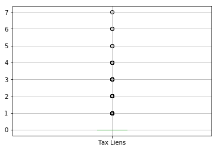

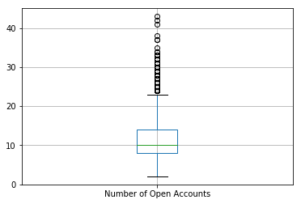

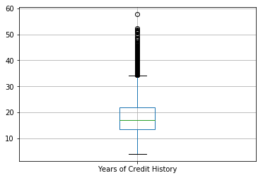

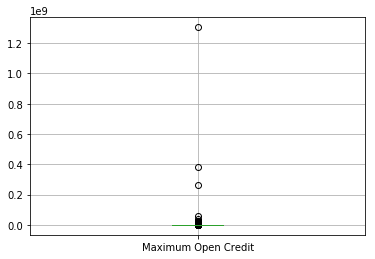

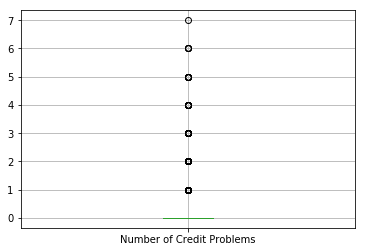

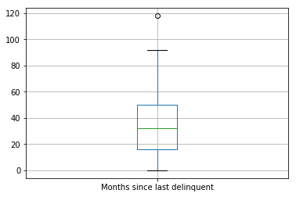

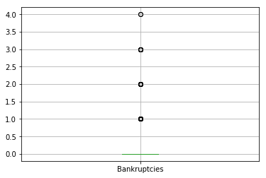

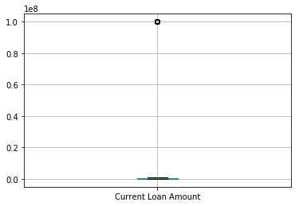

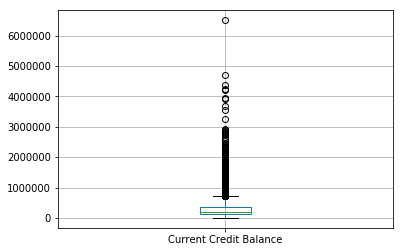

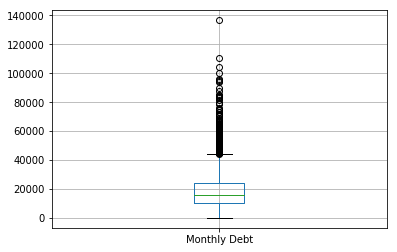

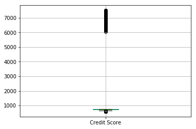

[1 more figures not shown]

```python
import matplotlib.pyplot as plt

for column in df:
    if column not in ['Home Ownership', 'Years in current job', 'Purpose', 'Term']:
        plt.figure()
        df.boxplot([column])
```

Выглядит не радужно. Посмотрим на данные для записей, имеющих выбросы. *C другой стороны, может быть это такой уровень зарплат* Далее эти графики используются для определения значения отсечки - всё, что указано как выбросы, стараюсь убирать.

```python
# df.loc[df['Annual Income'] > 0.4*(10**7)].shape -- >(91, 17)
df.loc[df['Annual Income'] > 0.27*(10**7)]
# выбросов всего 338 значений. При 7500 входных не очень много.
```

|  | Home Ownership | Annual Income | Years in current job | Tax Liens | Number of Open Accounts | Years of Credit History | Maximum Open Credit | Number of Credit Problems | Months since last delinquent | Bankruptcies | Purpose | Term | Current Loan Amount | Current Credit Balance | Monthly Debt | Credit Score | Credit Default |
| --- | --- | --- | --- | --- | --- | --- | --- | --- | --- | --- | --- | --- | --- | --- | --- | --- | --- |
| 17 | Home Mortgage | 3361898.0 | 3 years | 0.0 | 14.0 | 28.5 | 1042096.0 | 0.0 | NaN | 0.0 | debt consolidation | Long Term | 498872.0 | 689396.0 | 52249.0 | 644.0 | 1 |
| 109 | Home Mortgage | 2831190.0 | 3 years | 0.0 | 11.0 | 16.7 | 518188.0 | 0.0 | NaN | 0.0 | debt consolidation | Short Term | 393382.0 | 362938.0 | 26188.0 | 741.0 | 0 |
| 137 | Home Mortgage | 3694037.0 | 10+ years | 0.0 | 6.0 | 23.0 | 935814.0 | 0.0 | 4.0 | 0.0 | debt consolidation | Short Term | 137566.0 | 661922.0 | 23642.0 | 724.0 | 1 |
| 164 | Home Mortgage | 2899305.0 | 10+ years | 0.0 | 15.0 | 16.6 | 667480.0 | 0.0 | NaN | 0.0 | debt consolidation | Long Term | 783332.0 | 328016.0 | 64751.0 | 709.0 | 0 |
| 166 | Home Mortgage | 4580976.0 | 4 years | 0.0 | 18.0 | 25.5 | 1553530.0 | 0.0 | NaN | 0.0 | debt consolidation | Long Term | 99999999.0 | 633289.0 | 94674.0 | 727.0 | 0 |
| ... | ... | ... | ... | ... | ... | ... | ... | ... | ... | ... | ... | ... | ... | ... | ... | ... | ... |
| 7468 | Home Mortgage | 3084840.0 | 5 years | 0.0 | 10.0 | 18.9 | 998910.0 | 0.0 | NaN | 0.0 | debt consolidation | Long Term | 519552.0 | 138890.0 | 4859.0 | 746.0 | 0 |
| 7476 | Home Mortgage | 3358782.0 | 10+ years | 0.0 | 12.0 | 13.4 | 538340.0 | 0.0 | NaN | 0.0 | debt consolidation | Short Term | 324104.0 | 292429.0 | 22084.0 | 721.0 | 0 |
| 7478 | Home Mortgage | 3888160.0 | 6 years | 0.0 | 30.0 | 16.3 | 1435456.0 | 0.0 | 21.0 | 0.0 | debt consolidation | Short Term | 787864.0 | 402914.0 | 93640.0 | 703.0 | 0 |
| 7486 | Rent | 5327372.0 | 1 year | 0.0 | 7.0 | 12.1 | 605638.0 | 0.0 | NaN | 0.0 | debt consolidation | Short Term | 111760.0 | 292904.0 | 8080.0 | 750.0 | 0 |
| 7491 | Home Mortgage | 2833185.0 | 6 years | 0.0 | 18.0 | 21.3 | 280170.0 | 0.0 | 6.0 | 0.0 | debt consolidation | Short Term | 437404.0 | 108889.0 | 61150.0 | 704.0 | 0 |

338 rows × 17 columns

```python
# Посмотрим на средние значения и вид распределения без выбросов.
df.loc[df['Annual Income'] <= 0.27*(10**7)].describe()
```

|  | Annual Income | Tax Liens | Number of Open Accounts | Years of Credit History | Maximum Open Credit | Number of Credit Problems | Months since last delinquent | Bankruptcies | Current Loan Amount | Current Credit Balance | Monthly Debt | Credit Score | Credit Default |
| --- | --- | --- | --- | --- | --- | --- | --- | --- | --- | --- | --- | --- | --- |
| count | 5.605000e+03 | 5605.000000 | 5605.000000 | 5605.000000 | 5.605000e+03 | 5605.000000 | 2551.000000 | 5593.000000 | 5.605000e+03 | 5.605000e+03 | 5605.000000 | 5605.000000 | 5605.000000 |
| mean | 1.219352e+06 | 0.024978 | 11.010705 | 18.118145 | 7.080430e+05 | 0.168243 | 35.135633 | 0.121044 | 1.479824e+07 | 2.700966e+05 | 17172.250491 | 1160.729706 | 0.272614 |
| std | 5.188402e+05 | 0.232336 | 4.822276 | 7.001925 | 5.192977e+06 | 0.479849 | 21.609721 | 0.354072 | 3.514819e+07 | 2.567945e+05 | 10128.337909 | 1620.566989 | 0.445344 |
| min | 1.645970e+05 | 0.000000 | 2.000000 | 4.000000 | 0.000000e+00 | 0.000000 | 0.000000 | 0.000000 | 1.124200e+04 | 0.000000e+00 | 0.000000 | 585.000000 | 0.000000 |
| 25% | 8.244100e+05 | 0.000000 | 8.000000 | 13.400000 | 2.715460e+05 | 0.000000 | 17.000000 | 0.000000 | 1.814340e+05 | 1.119480e+05 | 9867.000000 | 711.000000 | 0.000000 |
| 50% | 1.137720e+06 | 0.000000 | 10.000000 | 16.800000 | 4.616700e+05 | 0.000000 | 33.000000 | 0.000000 | 3.129720e+05 | 2.029580e+05 | 15500.000000 | 731.000000 | 0.000000 |
| 75% | 1.536568e+06 | 0.000000 | 13.000000 | 21.500000 | 7.597040e+05 | 0.000000 | 51.000000 | 0.000000 | 5.349300e+05 | 3.453440e+05 | 22545.000000 | 743.000000 | 1.000000 |
| max | 2.698532e+06 | 6.000000 | 42.000000 | 57.700000 | 3.800523e+08 | 6.000000 | 92.000000 | 4.000000 | 1.000000e+08 | 4.209659e+06 | 70966.000000 | 7510.000000 | 1.000000 |

```python
df.describe() # без изменений по первому столбцу
```

|  | Annual Income | Tax Liens | Number of Open Accounts | Years of Credit History | Maximum Open Credit | Number of Credit Problems | Months since last delinquent | Bankruptcies | Current Loan Amount | Current Credit Balance | Monthly Debt | Credit Score | Credit Default |
| --- | --- | --- | --- | --- | --- | --- | --- | --- | --- | --- | --- | --- | --- |
| count | 5.943000e+03 | 7500.000000 | 7500.000000 | 7500.000000 | 7.500000e+03 | 7500.000000 | 3419.000000 | 7486.000000 | 7.500000e+03 | 7.500000e+03 | 7500.000000 | 5943.000000 | 7500.000000 |
| mean | 1.366392e+06 | 0.030133 | 11.130933 | 18.317467 | 9.451537e+05 | 0.170000 | 34.692600 | 0.117152 | 1.187318e+07 | 2.898332e+05 | 18314.454133 | 1151.087498 | 0.281733 |
| std | 8.453392e+05 | 0.271604 | 4.908924 | 7.041946 | 1.602622e+07 | 0.498598 | 21.688806 | 0.347192 | 3.192612e+07 | 3.178714e+05 | 11926.764673 | 1604.451418 | 0.449874 |
| min | 1.645970e+05 | 0.000000 | 2.000000 | 4.000000 | 0.000000e+00 | 0.000000 | 0.000000 | 0.000000 | 1.124200e+04 | 0.000000e+00 | 0.000000 | 585.000000 | 0.000000 |
| 25% | 8.443410e+05 | 0.000000 | 8.000000 | 13.500000 | 2.792295e+05 | 0.000000 | 16.000000 | 0.000000 | 1.801690e+05 | 1.142565e+05 | 10067.500000 | 711.000000 | 0.000000 |
| 50% | 1.168386e+06 | 0.000000 | 10.000000 | 17.000000 | 4.781590e+05 | 0.000000 | 32.000000 | 0.000000 | 3.095730e+05 | 2.093230e+05 | 16076.500000 | 731.000000 | 0.000000 |
| 75% | 1.640137e+06 | 0.000000 | 14.000000 | 21.800000 | 7.935015e+05 | 0.000000 | 50.000000 | 0.000000 | 5.198820e+05 | 3.604062e+05 | 23818.000000 | 743.000000 | 1.000000 |
| max | 1.014934e+07 | 7.000000 | 43.000000 | 57.700000 | 1.304726e+09 | 7.000000 | 118.000000 | 4.000000 | 1.000000e+08 | 6.506797e+06 | 136679.000000 | 7510.000000 | 1.000000 |

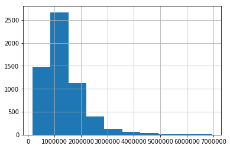

```python
df.loc[df['Annual Income'] <= 0.7*(10**7)]['Annual Income'].hist()
```

[output not shown]

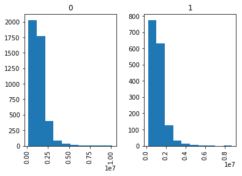

```python
df['Annual Income'].hist(by=df['Credit Default'])
```

[output not shown]

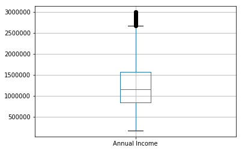

```python
df.loc[df['Annual Income'] <= 0.3*(10**7)].boxplot(['Annual Income'])
df.loc[df['Annual Income'] <= 0.4*(10**7)].shape
```

Видно, что гистограмма будет вытянута в сторону увеличения з/п, позже вернусь к нему, возможно, стоит провести нормализацию сначала.

Дальше Tax Liens. Взглянем на распределение тех значений, что меньше 1, т.к. у меня подозрение, что те, что выше - некорректные значения.

```
array([[<matplotlib.axes._subplots.AxesSubplot object at 0x000002924219AEF0>]],
      dtype=object)
```

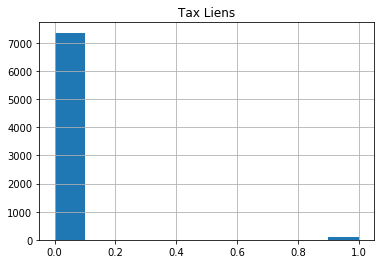

```python
df.loc[df['Tax Liens'] <= 1].hist(['Tax Liens'])
```

```
array([[<matplotlib.axes._subplots.AxesSubplot object at 0x000002923EAE40F0>]],
      dtype=object)
```

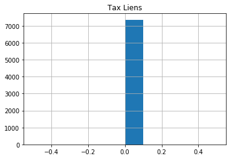

```python
# Ещё меньше
df.loc[df['Tax Liens'] <= 0.7].hist(['Tax Liens'])
```

```python
# похоже, что не тем путём. Если так
df['Tax Liens'].value_counts()
# Это похоже на количество налоговых обременений. С этим значениями можно ничего не делать, полагаю,
# они в подходящем виде.
```

```
0.0    7366
1.0      83
2.0      30
3.0      10
4.0       6
5.0       2
6.0       2
7.0       1
Name: Tax Liens, dtype: int64
```

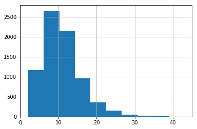

```python
# Количество счетов. Выглядят нормально, оставляем, как есть. Не смотря на то, что боксплот рисует выбросы,
# ситуация, когда у человека много счетов не будет аномальной с т.зр. здравого смысла
df['Number of Open Accounts'].hist()
```

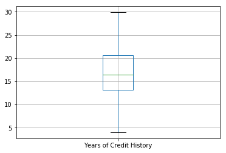

```python
# df['Years of Credit History'].value_counts()
#df['Years of Credit History'].loc[df['Years of Credit History'] < 30].hist()
# В оригинальном виде присутствуют значения до 60. Не уверен, что в то время существовала кредитная история.
# Таких значений около 25, думаю, не будет беды, если их убрать совсем или проигнорировать
df.loc[df['Years of Credit History'] < 30].boxplot(['Years of Credit History'])
```

[output not shown]

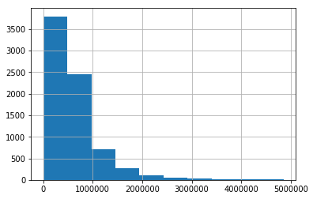

```python
df.loc[df['Maximum Open Credit'] < 0.5*10**7]['Maximum Open Credit'].hist()
df.loc[df['Maximum Open Credit'] < 0.5*10**7].shape
```

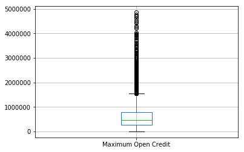

```python
# Вот такая картинка больше похожа на нормальную, нежели оригинальная. 52 выброшенных значения - норм.
df.loc[df['Maximum Open Credit'] < 0.5*10**7].boxplot(['Maximum Open Credit'])
```

```python
# Данные здесь выше выглядят достоверно
df['Number of Credit Problems'].value_counts()
```

```
0.0    6469
1.0     882
2.0      93
3.0      35
4.0       9
5.0       7
6.0       4
7.0       1
Name: Number of Credit Problems, dtype: int64
```

```
3419
```

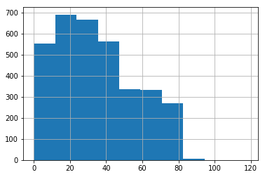

```python
# Больше половины этих данных отсутствуют. Есть мнение, что отсутствие данных - отсутствие просрочки, в ином случае
# стоит их игнорировать при обучении и предсказании
df['Months since last delinquent'].hist()
df['Months since last delinquent'].count()
# df['Months since last delinquent'].value_counts()
```

```python
# Число банкротств. Отсутствующие данные заменить нулём. Больше ничего с данными не делать.
df['Bankruptcies'].value_counts()
```

```
0.0    6660
1.0     786
2.0      31
3.0       7
4.0       2
Name: Bankruptcies, dtype: int64
```

```
(6630,)
```

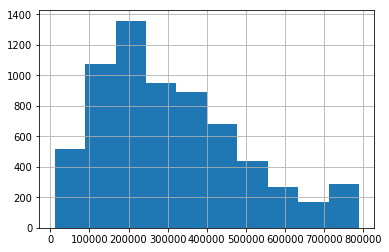

```python
# Current Loan Amount
# df['Current Loan Amount'].hist()
# Очень большое значение следует отсечь
df.loc[df['Current Loan Amount'] < 0.2*10**8]['Current Loan Amount'].hist()
df.loc[df['Current Loan Amount'] < 0.2*10**8]['Current Loan Amount'].shape
```